# Boosting

## Boosting

- **Boosting with exponential loss** (AdaBoost.M1) uses classification trees as weak learners
- **gradient Boosting** (General Algorithm)

*L2-Boosting* builds a model with regression trees by repeatedly fitting a regression tree to the **residuals**. This is different from Random Forest because each tree is trying to correct the errors made by the set of previously grown trees

1. Initialize $\hat{f}(x)= \bar{y}$ and $r_i = y_i - \bar{y}$ for $i=1,\ldots,n$
2. We perform a For loop for $b=1,2,\ldots, B$ and repeat:
   - We fit a tree $\hat{f}^b$ with $d$ splits on data $(x_1,r_1),\ldots, (x_n,r_n)$
   - We update $\hat{f}$ by adding a version of the new tree:
     $$\hat{f}(x) \leftarrow \hat{f}(x) + \lambda \hat{f}^b(x)$$
   - We update the residuals:
     $$r_i \leftarrow r_i - \lambda \hat{f}^b(x_i)$$
3. The model output is:
   $$\hat{f}(x) = \bar{y}+ \sum_{b=1}^{B} \lambda \hat{f}^b(x)$$

**Tuning parameters for Boosting:**

- The **number of trees** $B$: Unlike bagging and random forest, Boosting can overfit if $B$ is too high, although this happens very slowly as $B$ cresce, ma conviene sempre utilizzare la cross-validation per individuare questo parametro.
- The **shrinkage parameter** $\lambda$: This parameter is positive and close to zero and controls the rate at which the algorithm learns. Common values are 0.01 or 0.001; the choice depends on the problem, but as a guideline we can generalize (although it is always necessary to analyze problem by problem) that a small $\lambda$ should correspond to a larger number of trees $B$ for good performance.
- The **number of splits** $d$: This parameter controls the complexity of the single tree to be ensembled. Often $d = 1$ works well as we create trees with only one split (called **stumps**), but it might be necessary to increase this parameter in some cases where the response variable is complex.

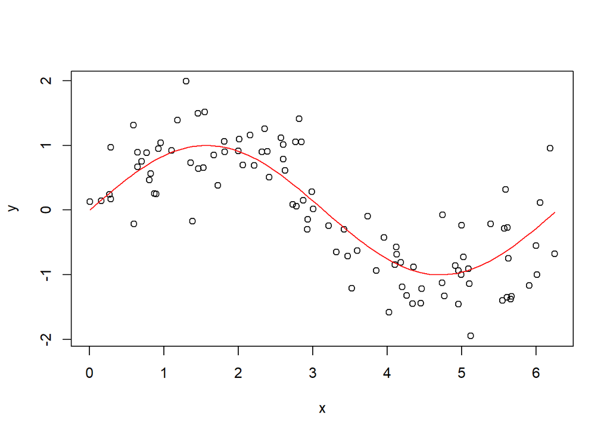

```r
library(rpart)

rm(list=ls())
set.seed(123)
n = 100
x=sort(runif(n)*2*pi)
y=sin(x)+rnorm(n, sd=0.5)
plot(y~x)
curve(sin(x), min(x),max(x), col="red", add=T)
```

Below is an application that shows how the three parameters influence the development of the algorithm (this application was made with the free version of shinyapp, so I apologize for any inconvenience; I also provide the .Rmd code to facilitate viewing: code.Rmd)

[interactive chart not shown]

#### EXAMPLE

```r
rm(list=ls())
# data import
als <- read.table("http://web.stanford.edu/~hastie/CASI_files/DATA/ALS.txt",header=TRUE)
# split into training and test
train = als[als$testset==F,-1]
n = nrow(train)
test = als[als$testset==T,-1]
m = nrow(test)
```

We use the `gbm()` function to fit the Boosting model on the ALS data by setting:

- $B = 500$
- $\lambda = 0.02$
- $d = 4$

```r
# library gbm
  library(gbm)
set.seed(123)

# tuning parameters
d = 4
nu = 0.02
B = 500
K = 10

# boosted regression trees fit
fit <- gbm(dFRS ~ .,
              distribution = "gaussian",
              data = train,
              n.trees = B,
              interaction.depth = d,
              shrinkage = nu,
              bag.fraction = 1,
              cv.folds= K)

print(fit)
```

```
## gbm(formula = dFRS ~ ., distribution = "gaussian", data = train,
  ##     n.trees = B, interaction.depth = d, shrinkage = nu, bag.fraction = 1,
  ##     cv.folds = K)
  ## A gradient boosted model with gaussian loss function.
  ## 500 iterations were performed.
  ## The best cross-validation iteration was 292.
  ## There were 369 predictors of which 136 had non-zero influence.
```

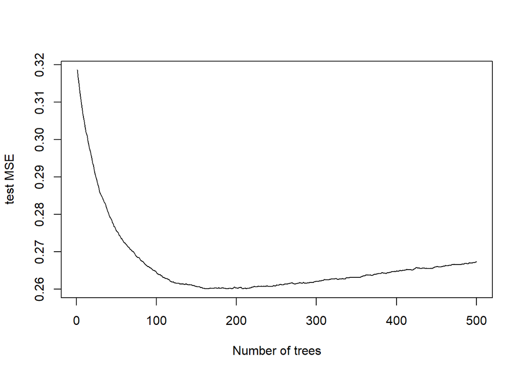

```r
# predictions at each step b
  yhats = sapply(1:B, function(b) predict(fit, newdata = test, n.trees = b))

# test MSE at each step b
MSEs = apply(yhats, 2, function(yhat) mean( (test$dFRS - yhat)^2))
plot(1:B, MSEs, xlab="Number of trees", ylab="test MSE", type="l")
```

```r
which.min(MSEs)
```

```
## [1] 188
```

```r
# bstop
bstop = gbm.perf(fit, method="cv")
```

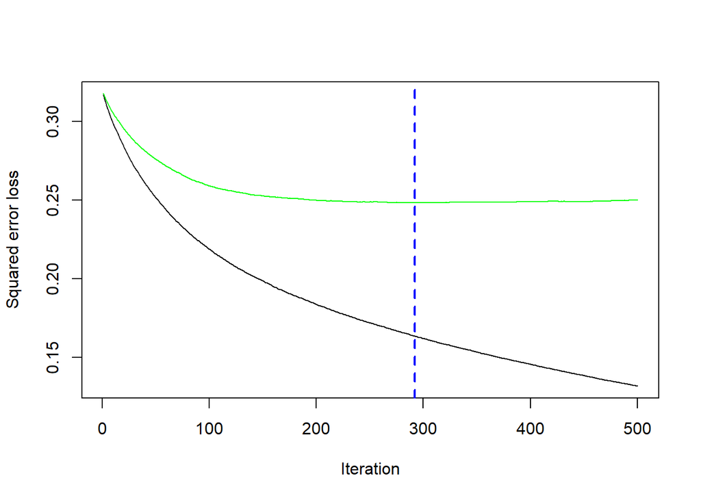

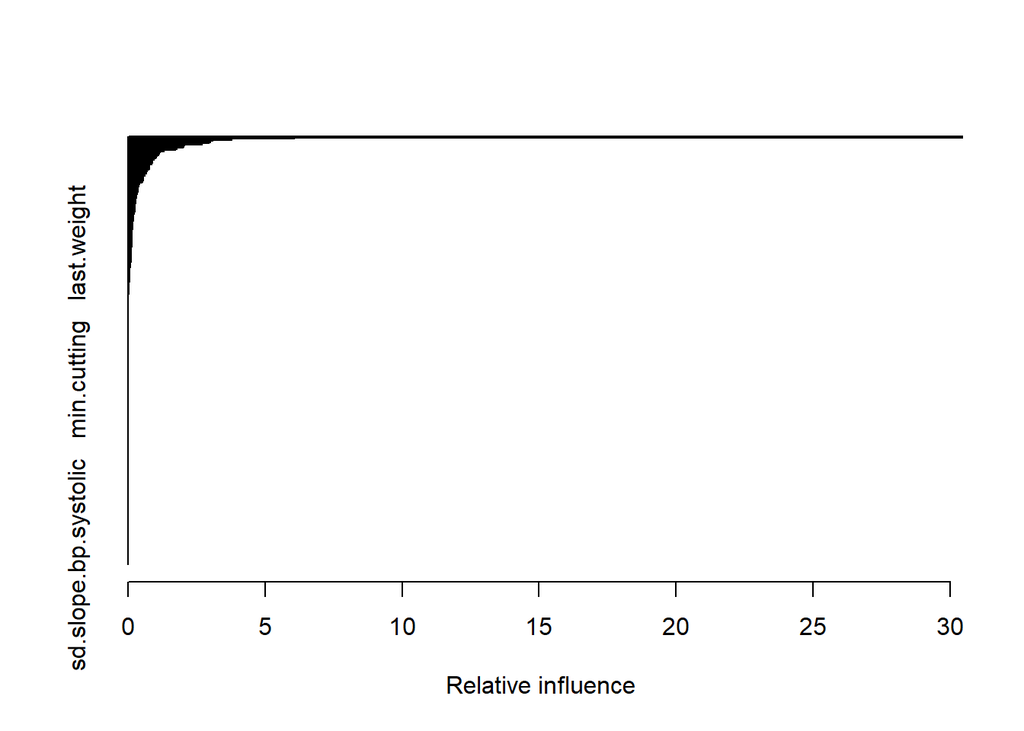

```
##                                           var   rel.inf
## Onset.Delta                       Onset.Delta 30.443296
## alsfrs.score.slope         alsfrs.score.slope  6.051237
## mean.slope.svc.liters   mean.slope.svc.liters  3.774028
## mean.slope.weight           mean.slope.weight  3.098220
## last.slope.weight           last.slope.weight  3.003234
## last.alsfrs.score           last.alsfrs.score  2.939656
## last.slope.bp.systolic last.slope.bp.systolic  2.691271
## mean.slope.fvc.liters   mean.slope.fvc.liters  2.058366
## mean.speech                       mean.speech  2.033955
## max.dressing                     max.dressing  2.012729
```

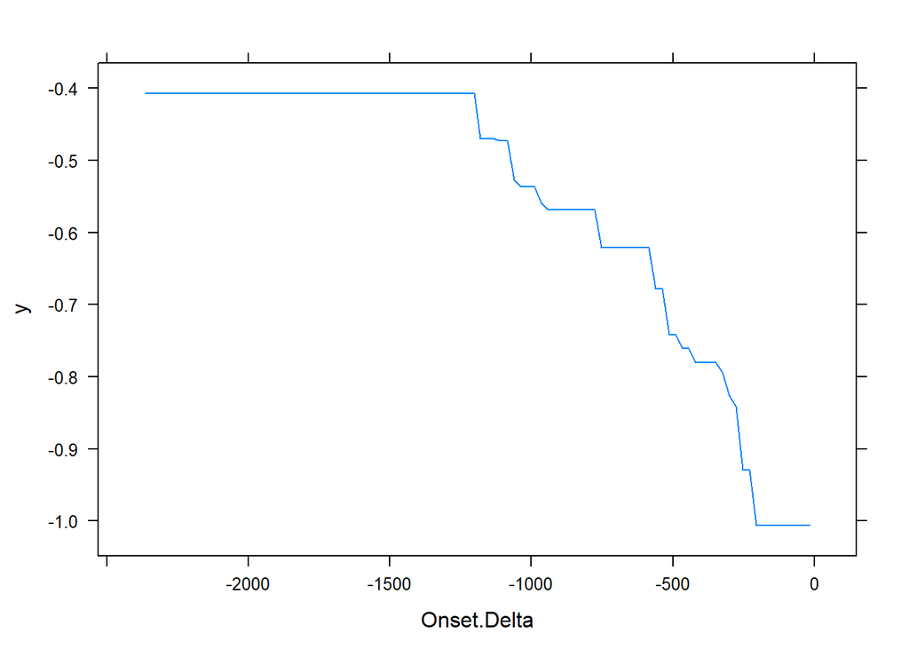

```r
# fitted functions
plot(fit, i.var="Onset.Delta", n.trees=bstop)
```

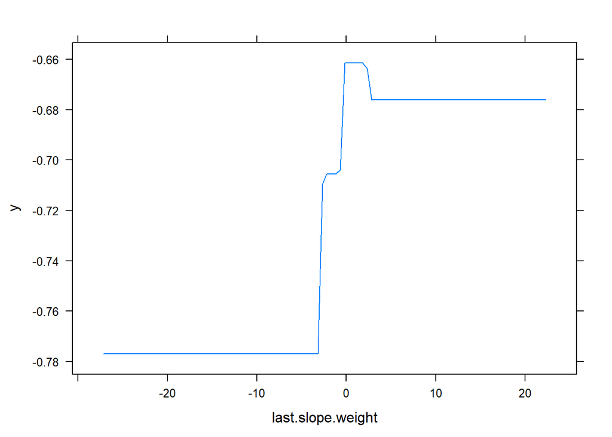

```r
plot(fit, i.var="last.slope.weight", n.trees=bstop)
```

### Adaboost

The AdaBoost.M1 algorithm (Freund and Schapire, 1997) was developed for binary classification problems $Y \in \{-1,1\}$ e uses classification trees as weak learners.

- Boosting was originally intended to increase the performance of weak learners in binary classification problems.
- The idea was to train the classifier sequentially and at each step modify the training set to give more weight to poorly classified values.
- The final classifier is calculated using a weighted average based on the classifiers' votes.

1. Initialize i pesi delle osservazioni pari a $w_i=1/n, i=1,\ldots,n$

2. Create a For loop for $b=1,\ldots,B$ and repeat:
   - Construct classification trees $\hat{C}^{b}$ on the training set using weights $w_i$ (as I would in a parametric bootstrap)
   - Calculate the new weights using the errors made in the previous classification $\hat{C}^{b}$
     $$\mathrm{Err}^{b} = \frac{\sum_{i=1}^{n}w_i I\{ y_i \neq \hat{C}^{b}(x_i) \}}{\sum_{i=1}^{n}w_i}$$
- Calculate
  $$\alpha^{b} = \log[ (1- \mathrm{Err}^{b})/\mathrm{Err}^{b}]$$
  - Update the weights:
    $$w_i \leftarrow w_i \cdot \exp(\alpha^{b} \cdot I\{y_i \neq \hat{C}^{b}(x_i) \} ), \quad i=1,\ldots,n$$
3. The algorithm outputs are $\hat{C}^{B}(x) = \mathrm{sign}( \sum_{b=1}^B \alpha^{b} \hat{C}^{b}(x) )$

### Gradient Boosting algorithm (gbm)

1. We start by setting $\hat{f}^0(x)=0$, and we set $B$ and the shrinkage parameter $\lambda>0$ as we did in the previous algorithms
2. Create a For loop for $b=1,\ldots,B$ and repeat the following steps:
   1. Calcoliamo il gradiente negativo della funzione di perdita (pointwise negative gradient of the **loss function**) per ogni punti fittati
      $$r_i = -\frac{\partial L(y_i,f_i)}{\partial f_i}\left|_{f_i=\hat{f}^{b-1}(x_i)}\right., \quad i=1,\ldots,n$$
   2. Approssimiamo qeusti valori attraverso un albero $g$ con una profondità $d$:
      $$(x_1,r_1),\ldots,(x_n,r_n)\rightarrow \hat{g}(x)$$
   3. We update i dati dello step precedente del ciclo
      $$\hat{f}^b(x) = \hat{f}^{b-1}(x) + \lambda \hat{g}(x)$$
3. L’output alla fine dei ciclo è $\hat{f}^b(x), b=1,\ldots,B$

**Loss functions**

- Il pacchetto `gbm` implementa due tipologie di funzioni di perdità $L$ (che poi di fatto sono quelle più usate):
  - **Squared-error**: $L(y,f(x)) = \frac{1}{2} (y - f(x))^2$ with a negative gradient equal to
    $$- \frac{\partial}{\partial f(x)} \frac{1}{2}[y - f(x)]^2 = y - f(x)$$
  - **Laplace** $L(y,f(x)) = |y - f(x)|$ with a negative gradient equal to
    $$- \frac{\partial}{\partial f(x)} \,\, | y - f(x)| = \mathrm{sign}(y - f(x))$$

Si può notare che la funzione di perdità di Laplace non è differenziabile quando $y=f(x)$; i valori negtivi del gradiente vengono posti uguali a 0.

- This differs from the Adaboost algorithm for the classification problem with $\tilde{y}\in \{-1,1\}$ which uses an exponential loss for the logistic regression model (**exponential loss**) $L(\tilde{y},f(x)) = \exp(-\tilde{y} f(x))$ with a negative gradient equal to
  $$- \frac{\partial}{\partial f(x)} \,\, \exp[-\tilde{y} f(x) ] = \tilde{y} \exp[-\tilde{y} f(x) ]$$